# Introduction to R shiny package

Hakan Turgay & Bertan Taylan

# Chapter 1 Motivation, Basic R-Shiny Package and Example

## Motivation

- Scientists mostly use R to process their analyzes
- Presenting/Sharing their findings are usually done in static format
- Problem : They cannot present additional questions directly
- Simple idea: Immigrating ratios from a specific region of Turkey due to years and also forecasts about these ratios (e.g. Journalist)

## What is Shiny package?

- Shiny is an R package that makes it easy to build interactive web applications (apps) straight from R. This lesson will get you started building Shiny apps right away.
- Build useful web applications with only a few lines of code—no JavaScript required.
- Shiny applications are automatically “live” in the same way that spreadsheets are live. Outputs change instantly as users modify inputs, without requiring a reload of the browser.
- Shiny user interfaces can be built entirely using R, or can be written directly in HTML, CSS, and JavaScript for more flexibility.
- Pre-built output widgets for displaying plots, tables, and printed output of R objects.

## Basically

R Shiny = R + interactivity + web made easy

[figure not shown]

## Install Shiny Package

If you still haven’t installed the Shiny package, open an R session, connect to the internet, and run

```r
install.packages("shiny")
```

## First App in Shiny

```r
library(shiny)
runExample("01_hello")
```

Code Output

[figure not shown]

## More Example

```r
runExample("01_hello")      # a histogram
runExample("02_text")       # tables and data frames
runExample("03_reactivity") # a reactive expression
runExample("04_mpg")        # global variables
runExample("05_sliders")    # slider bars
runExample("06_tabsets")    # tabbed panels
runExample("07_widgets")    # help text and submit buttons
runExample("08_html")       # Shiny app built from HTML
runExample("09_upload")     # file upload wizard
runExample("10_download")   # file download wizard
runExample("11_timer")      # an automated timer
```

# Chapter 2 Structure of a Shiny App

## Main Structure

- ui: Nested R functions that assemble an HTML user interface for the app
- server : A function with instructions on how to build and rebuild the R objects displayed in the UI
- shinyApp : Combines ui and server into a functioning app
- Save the template as app.R
- a call to the shinyApp function

```r
library(shiny)

ui <- fluidPage(

)

server <- function(input, output, session) {

}

shinyApp(ui, server)
```

## Alternative Approach

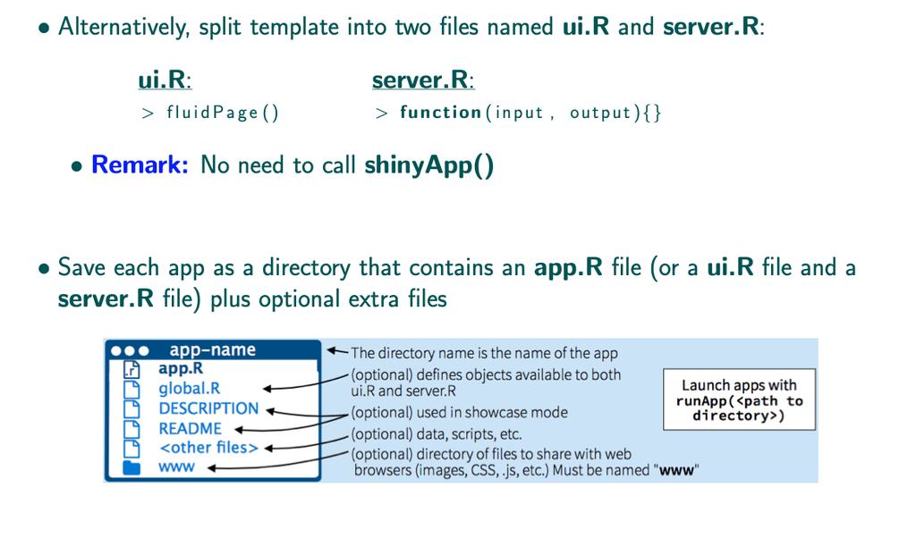

## Say Hello with Shiny

```r
library(shiny)
ui <- fluidPage(
    "Hello Shiny Package"
    )

server <- function(input, output) {

}

shinyApp(ui = ui, server = server)
```

# Chapter 3 Inputs and Outputs

## Overview

Build your app around inputs and outputs

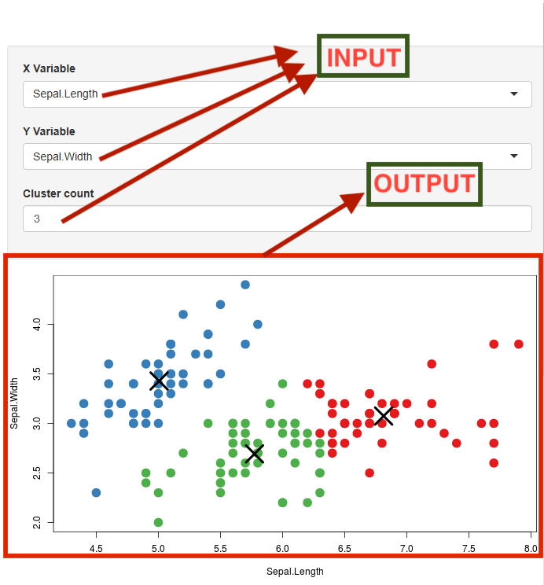

## Input

```r
sliderInput(inputId = "num",
  label = "Choose a number",
  value = 25, min = 1, max = 100)
```

```r
library(shiny)
ui <- fluidPage(
    sliderInput(inputId = "num",
                label = "Choose a number",
                value = 25, min = 1, max = 100)
    )

server <- function(input, output) {

}

shinyApp(ui = ui, server = server)
```

## Code Output

working code:

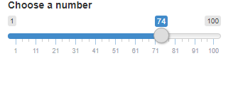

## Input Syntax

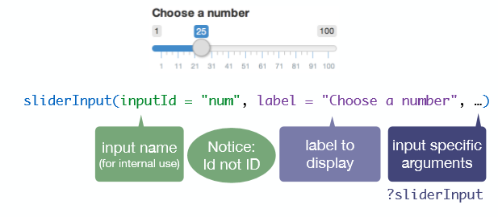

## Entegration Input and Output

Use 3 rules to write the server function

```r
server <- function(input, output) {




}
```

## 1 - Save objects to display to output$

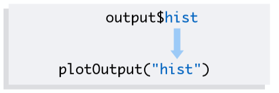

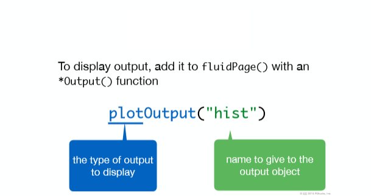

```r
server <- function(input, output) {
  output$hist <- # code
}
```

## 2 - Build objects to display with render*()

```r
server <- function(input, output) {
  output$hist <- renderPlot({

   #code

  })
}
```

## Render Method

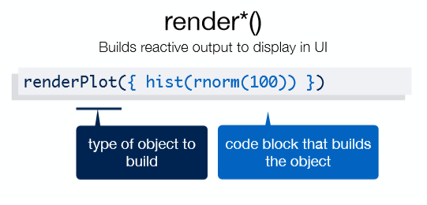

```r
server <- function(input, output) {
  output$hist <- renderPlot({

    title <- "100 random normal values"

    hist(rnorm(100), main = title)

  })
}
```

## …and more “Render Method” example

[figure not shown]

## 3 - Access input values with input$

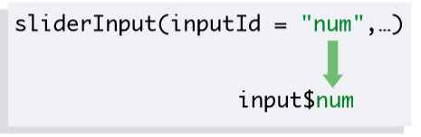

```r
server <- function(input, output) {

  output$hist <- renderPlot({
  hist(rnorm(input$num))

  })

}
```

## Result (Reactivity)

Reactivity automatically occurs whenever you use an input value to render an output object

```r
library(shiny)
ui <- fluidPage(
    sliderInput(inputId = "num",
                label = "Choose a number",
                value = 25, min = 1, max = 100),
    plotOutput("hist")
    )

server <- function(input, output) {
    output$hist <- renderPlot({
        hist(rnorm(input$num))
    })
}

shinyApp(ui = ui, server = server)
```

## Code Output

working code:

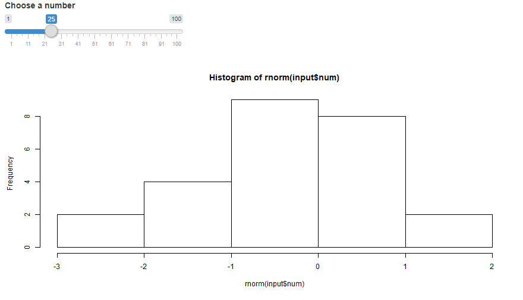

# Chapter 4 Using Checkbox in Shiny

## Reviewing an Example

```r
library(shiny)
runExample("02_text")
```

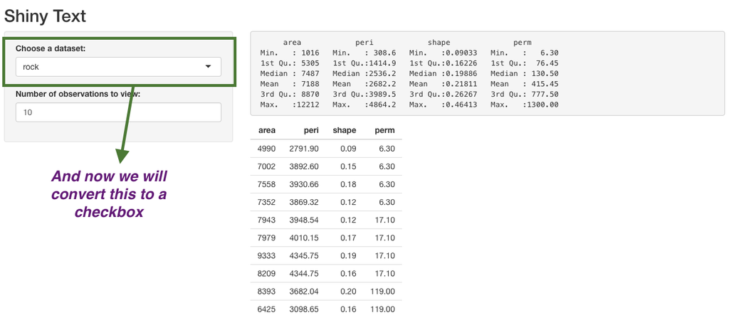

## Starting to Code Analysis

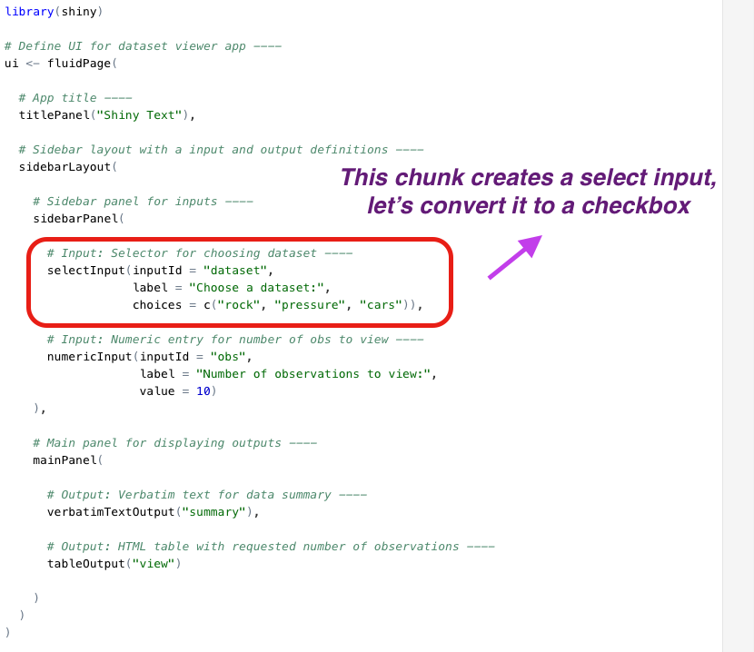

## Change code

```r
library(shiny)

ui <- fluidPage(
  titlePanel("Shiny Text"),
  sidebarLayout(

    sidebarPanel(

      checkboxGroupInput("dataset", "Choose a dataset:",
                         c("rock", "pressure", "cars"),
                         selected = "rock"),

      numericInput(inputId = "obs",
                   label = "Number of observations to view:",
                   value = 10)
    ),

    mainPanel(
      verbatimTextOutput("summary"),
      tableOutput("view")
    )
  )
)
```

## Result

working code:

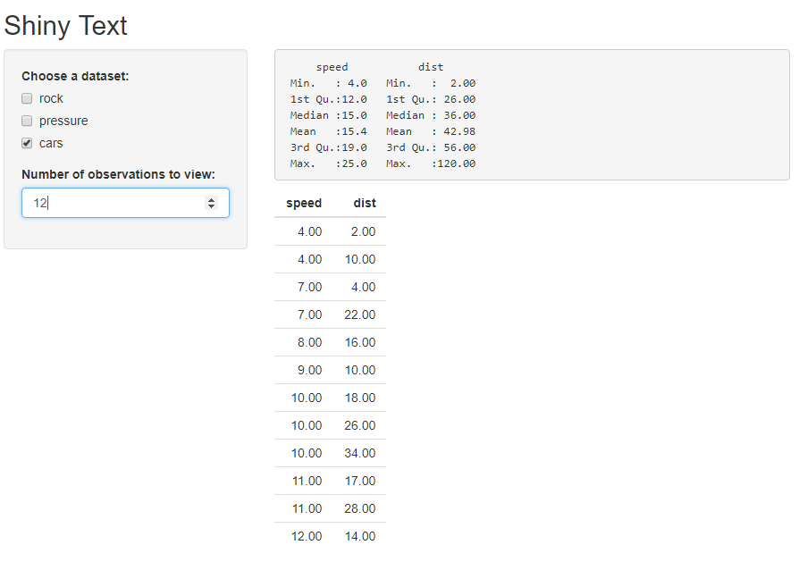